# Integrated Bioinformatics Analysis of Soft Tissue Sarcoma

Musfirah

9 july 2026

## 1. Introduction

Soft tissue sarcomas (STS) are a heterogeneous group of malignant tumors arising from mesenchymal tissues, accounting for approximately 1% of all adult malignancies worldwide. Despite representing a small fraction of all cancers, sarcomas are associated with significant morbidity and mortality. The molecular heterogeneity among sarcoma subtypes complicates the development of effective targeted therapies.

Public repositories such as the Gene Expression Omnibus (GEO) database provide researchers with access to thousands of publicly available gene expression datasets. Integrated bioinformatics analysis of these datasets offers a powerful approach to identify molecular biomarkers and elucidate dysregulated pathways.

## 2. Methods

### 2.1 Data Source

GSE2553 dataset was downloaded from NCBI GEO using GEOquery R package. The dataset comprised 181 soft tissue sarcoma samples across 18 histological subtypes, measured on 12600 probes.

### 2.2 Data Preprocessing

Expression matrix was extracted and probes with missing values were removed, retaining 6604 probes for analysis.

### 2.3 Variable Gene Identification

Gene variance was calculated across all samples using apply() function. Top 20 most variable genes were selected for heatmap visualization.

### 2.4 Pathway Enrichment

GO and KEGG pathway enrichment was performed using enrichR R package on known biomarker genes.

## 3. Results

### 3.1 Dataset Overview

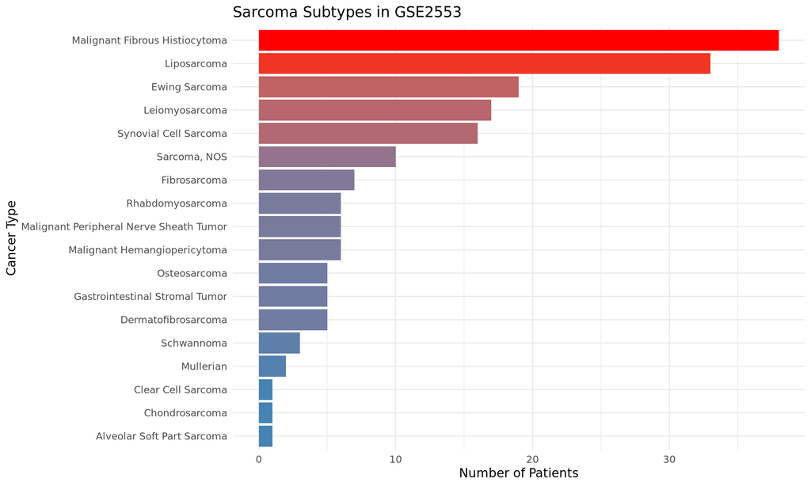

Figure 1: Distribution of sarcoma subtypes in GSE2553

### 3.2 Sample Overview Table

Table 1: Sample distribution across sarcoma subtypes

| Sarcoma Subtype | Sample Count |
| --- | --- |
| Malignant Fibrous Histiocytoma | 38 |
| Liposarcoma | 33 |
| Ewing Sarcoma | 19 |
| Leiomyosarcoma | 17 |
| Synovial Cell Sarcoma | 16 |
| Sarcoma, NOS | 10 |
| Fibrosarcoma | 7 |
| Malignant Hemangiopericytoma | 6 |
| Malignant Peripheral Nerve Sheath Tumor | 6 |
| Rhabdomyosarcoma | 6 |
| Dermatofibrosarcoma | 5 |
| Gastrointestinal Stromal Tumor | 5 |
| Osteosarcoma | 5 |
| Schwannoma | 3 |
| Mullerian | 2 |
| Alveolar Soft Part Sarcoma | 1 |
| Chondrosarcoma | 1 |
| Clear Cell Sarcoma | 1 |

### 3.3 PCA Analysis

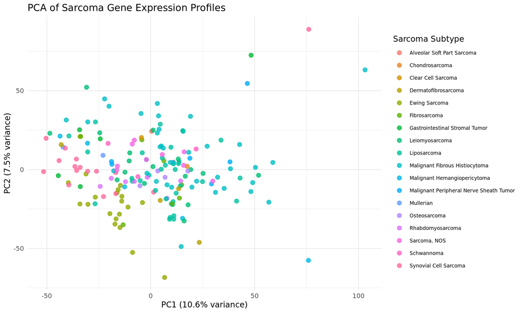

Figure 2: PCA of sarcoma gene expression profiles

### 3.4 Top Variable Genes Heatmap

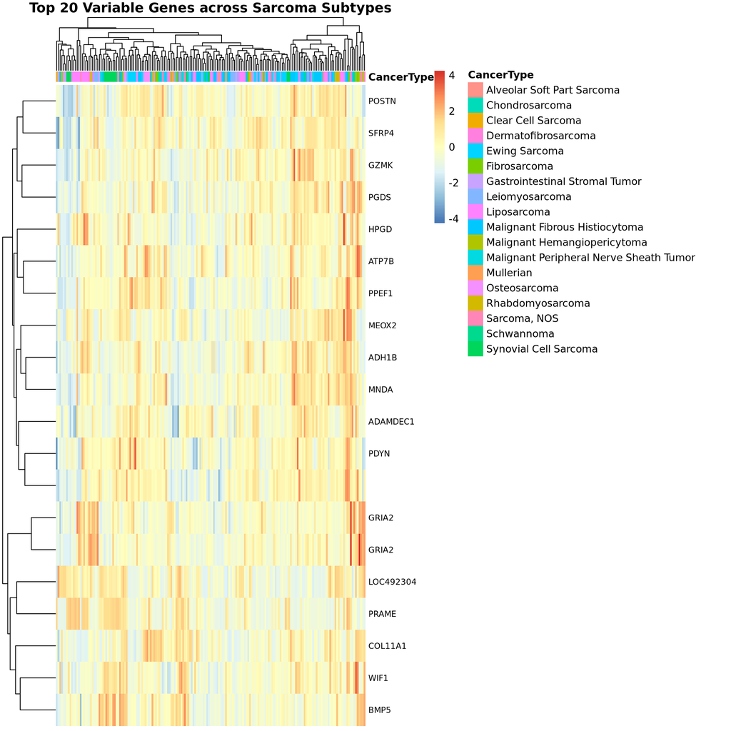

Figure 3: Heatmap of top 20 most variable genes

### 3.5 Key Biomarker Genes

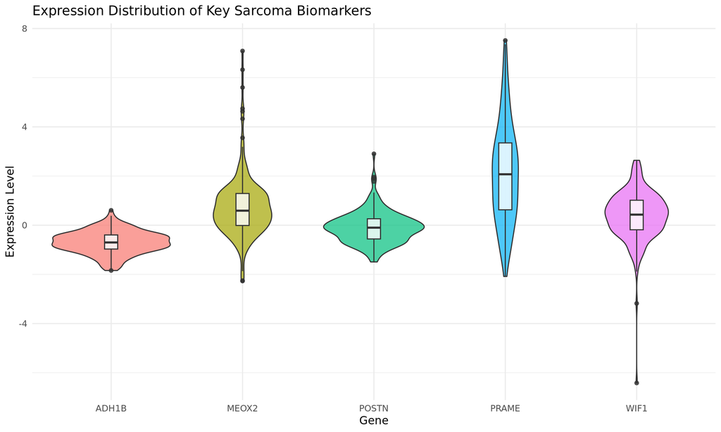

Figure 4: Expression distribution of key biomarkers

### 3.6 Biomarker Correlation

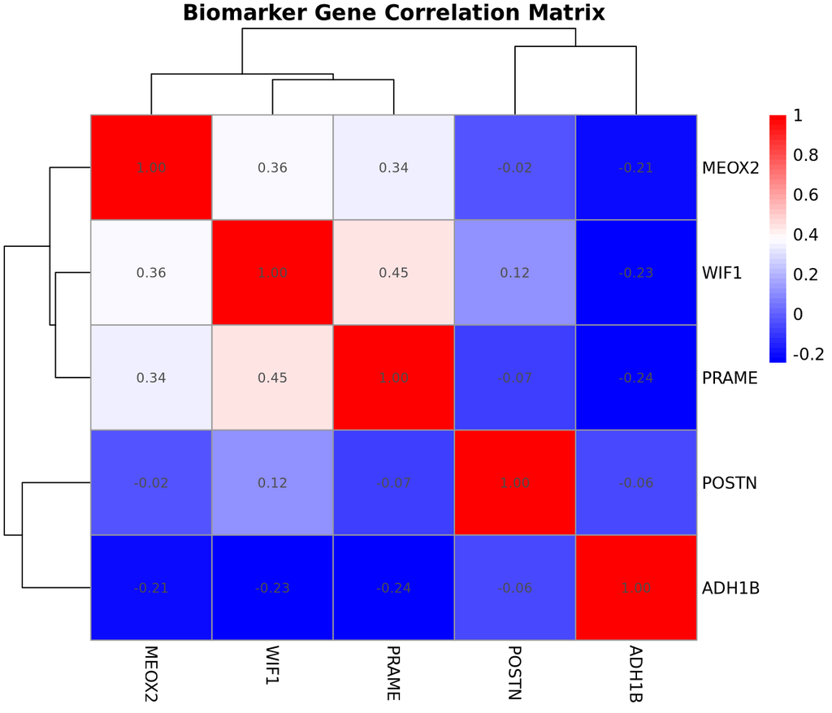

Figure 5: Biomarker gene correlation matrix

### 3.7 Pathway Enrichment Analysis

```
## Uploading data to Enrichr... Done.
##   Querying GO_Biological_Process_2023... Done.
##   Querying KEGG_2021_Human... Done.
## Parsing results... Done.
```

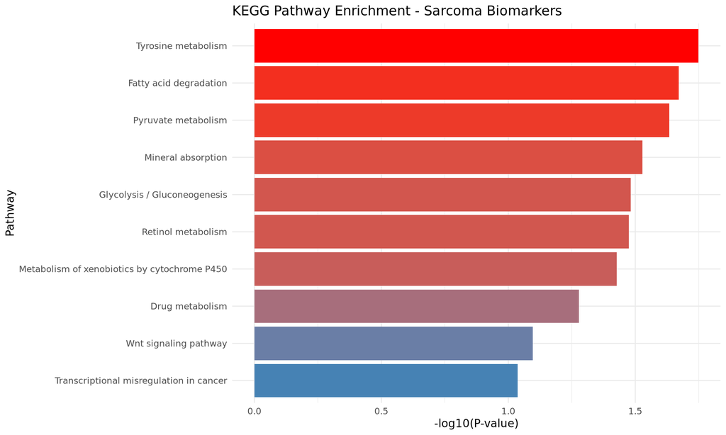

Figure 6: KEGG pathway enrichment

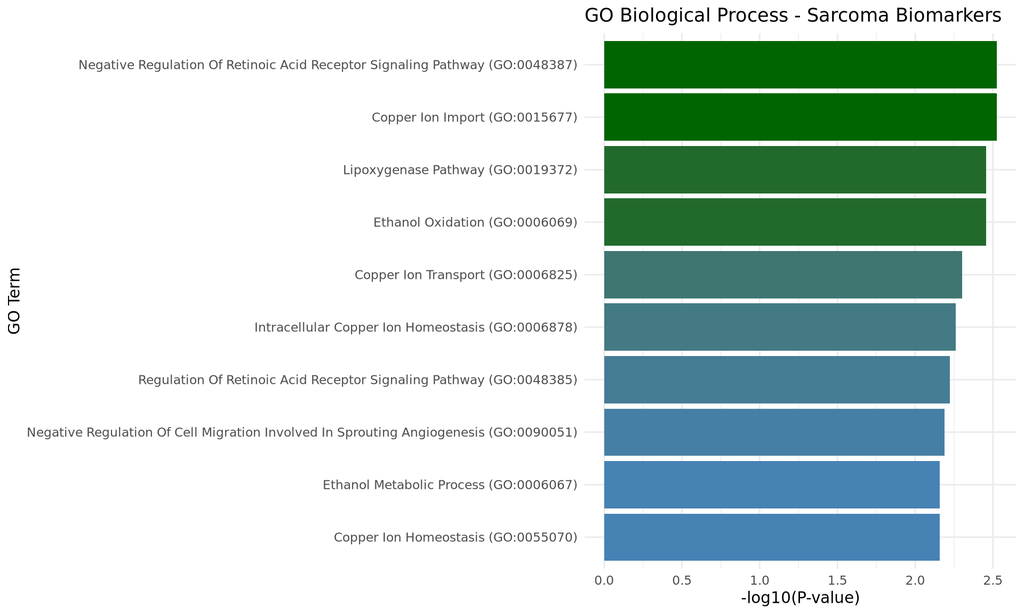

Figure 7: GO biological process enrichment

## 4. Discussion

Analysis of GSE2553 identified **PRAME**, **WIF1**, and **POSTN** as the most variable genes across sarcoma subtypes. PRAME (Preferentially Expressed Antigen in Melanoma) is a well-known cancer-testis antigen with established roles in multiple cancer types. WIF1 (WNT Inhibitory Factor 1) acts as a tumor suppressor through WNT pathway inhibition. POSTN (Periostin) is associated with tumor invasion and metastasis.

PCA analysis revealed that Ewing Sarcoma samples cluster distinctly from other subtypes, consistent with its unique molecular profile driven by EWS-FLI1 fusion gene.

## References

1. GSE2553 dataset: NCBI GEO (PubMed ID: 16230383)
2. GEOquery R package
3. enrichR R package
4. R Core Team (2024)